# IMDb Movie Review Sentiment Analysis

# 21 20. Ridge-Regularised Logistic Regression Model

A logistic regression model with L2 (Ridge) regularisation is trained using `glmnet` with `alpha = 0`. The model predicts positive-class probabilities for the test reviews, which are converted into class predictions using a threshold of 0.5.

```r
set.seed(123)

ridge_model <- glmnet(
  x = dtm_train,
  y = y_train,
  family = "binomial",
  alpha = 0,
  nlambda = 30,
  maxit = 100000
)

class(ridge_model)
```

```
## [1] "lognet" "glmnet"
```

```r
ridge_lambda <- ridge_model$lambda[15]

ridge_prob <- predict(
  ridge_model,
  newx = dtm_test,
  type = "response",
  s = ridge_lambda
)

head(ridge_model$lambda)
```

```
## [1] 129.55049  94.29921  68.63996  49.96271  36.36762  26.47183
```

```r
length(ridge_model$lambda)
```

```
## [1] 30
```

```r
tail(ridge_model$lambda)
```

```
## [1] 0.06340073 0.04614910 0.03359171 0.02445125 0.01779795 0.01295505
```

```r
ridge_pred <- ifelse(ridge_prob > 0.5, 1, 0)

head(ridge_prob)
```

```
##   s=1.518464
## 1  0.7456729
## 2  0.4512948
## 3  0.6564391
## 4  0.2016783
## 5  0.3005473
## 6  0.5679243
```

```r
length(ridge_pred)
```

```
## [1] 9917
```

```r
ridge_cm <- table(
  Actual = y_test,
  Predicted = ridge_pred
)

ridge_cm
```

```
##       Predicted
## Actual    0    1
##      0 4297  643
##      1  522 4455
```

```r
ridge_accuracy <- sum(diag(ridge_cm)) / sum(ridge_cm)
ridge_precision <- 4455 / (4455 + 643)
ridge_recall <- 4455 / (4455 + 522)

ridge_f1 <- 2 * (
  ridge_precision * ridge_recall
) / (
  ridge_precision + ridge_recall
)

ridge_accuracy
```

```
## [1] 0.882525
```

```r
ridge_precision
```

```
## [1] 0.8738721
```

```r
ridge_recall
```

```
## [1] 0.8951175
```

```r
ridge_f1
```

```
## [1] 0.8843672
```

```r
ridge_result <- data.frame(
  Model = "Ridge classifier",
  Accuracy = ridge_accuracy,
  Precision = ridge_precision,
  Recall = ridge_recall,
  F1 = ridge_f1
)

ridge_result
```

| Model | Accuracy | Precision | Recall | F1 |
| --- | --- | --- | --- | --- |
| Ridge classifier | 0.882525 | 0.8738721 | 0.8951175 | 0.8843672 |

# 22 21. Model Performance Comparison

The performance metrics from the four models are combined into one table. A grouped bar chart compares accuracy, precision, recall, and F1-score across the models.

```r
model_comparison <- bind_rows(
  logistic_result,
  naive_bayes_result,
  svm_result,
  ridge_result
)

model_comparison
```

| Model | Accuracy | Precision | Recall | F1 |
| --- | --- | --- | --- | --- |
| Logistic Regression | 0.8511647 | 0.8249490 | 0.8929074 | 0.8575839 |
| Naive Bayes | 0.8567107 | 0.8710351 | 0.8386578 | 0.8545399 |
| Linear SVM | 0.8641726 | 0.8588630 | 0.8742214 | 0.8664742 |
| Ridge classifier | 0.8825250 | 0.8738721 | 0.8951175 | 0.8843672 |

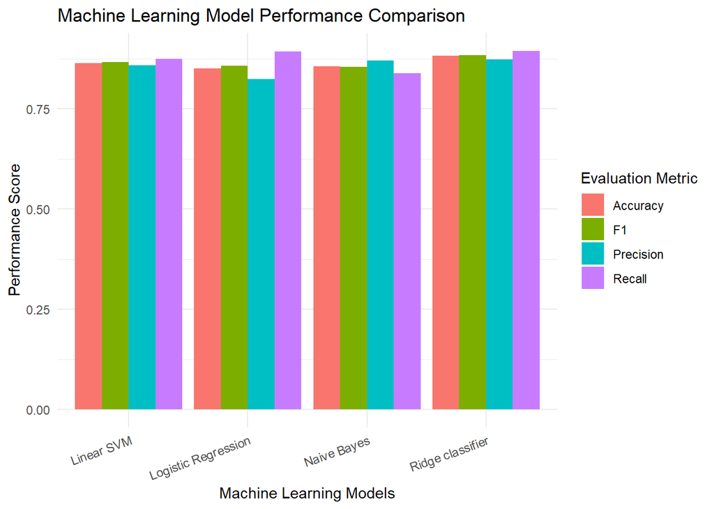

```r
write.csv(
  model_comparison,
  "model_comparison.csv",
  row.names = FALSE
)

model_comparison_long <- model_comparison %>%
  pivot_longer(
    cols = c(Accuracy, Precision, Recall, F1),
    names_to = "Metric",
    values_to = "Score"
  )

ggplot(
  model_comparison_long,
  aes(x = Model, y = Score, fill = Metric)
) +
  geom_col(position = "dodge") +
  labs(
    title = "Machine Learning Model Performance Comparison",
    x = "Machine Learning Models",
    y = "Performance Score",
    fill = "Evaluation Metric"
  ) +
  theme_minimal() +
  theme(
    axis.text.x = element_text(angle = 20, hjust = 1)
  )
```

# 23 22. Confusion Matrix Visualisations

Confusion matrices show the number of correct and incorrect predictions made by each model. The visualisations compare actual sentiment labels with predicted sentiment labels.

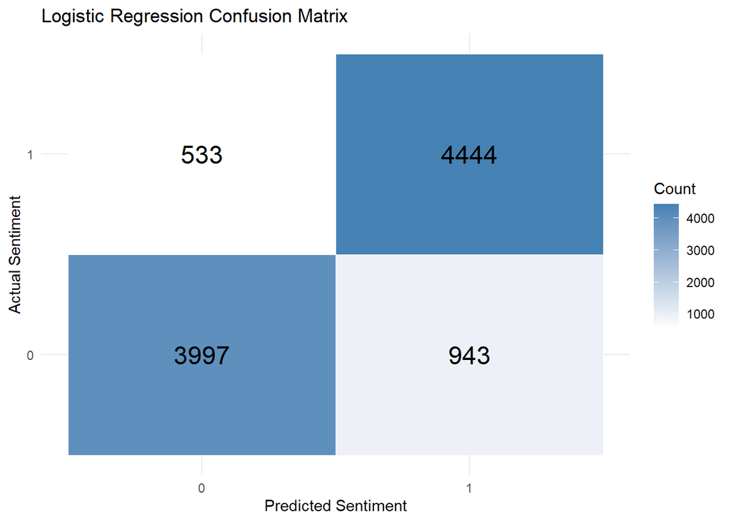

```r
logistic_cm_df <- as.data.frame(logistic_cm)

ggplot(
  logistic_cm_df,
  aes(x = Predicted, y = Actual, fill = Freq)
) +
  geom_tile(color = "white") +
  geom_text(aes(label = Freq), size = 6) +
  scale_fill_gradient(low = "white", high = "steelblue") +
  labs(
    title = "Logistic Regression Confusion Matrix",
    x = "Predicted Sentiment",
    y = "Actual Sentiment",
    fill = "Count"
  ) +
  theme_minimal()
```

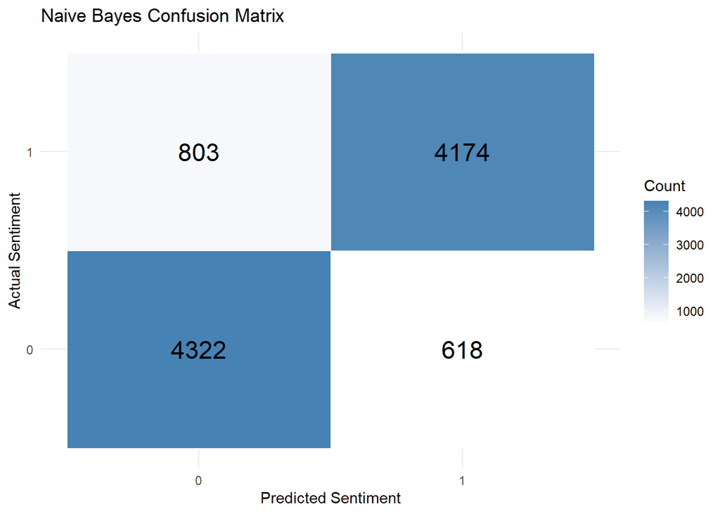

```r
naive_bayes_plot <- as.data.frame(as.table(naive_bayes_cm))
names(naive_bayes_plot) <- c("Actual", "Predicted", "Count")

ggplot(
  naive_bayes_plot,
  aes(x = Predicted, y = Actual, fill = Count)
) +
  geom_tile(color = "white") +
  geom_text(aes(label = Count), size = 6) +
  scale_fill_gradient(low = "white", high = "steelblue") +
  labs(
    title = "Naive Bayes Confusion Matrix",
    x = "Predicted Sentiment",
    y = "Actual Sentiment",
    fill = "Count"
  ) +
  theme_minimal()
```

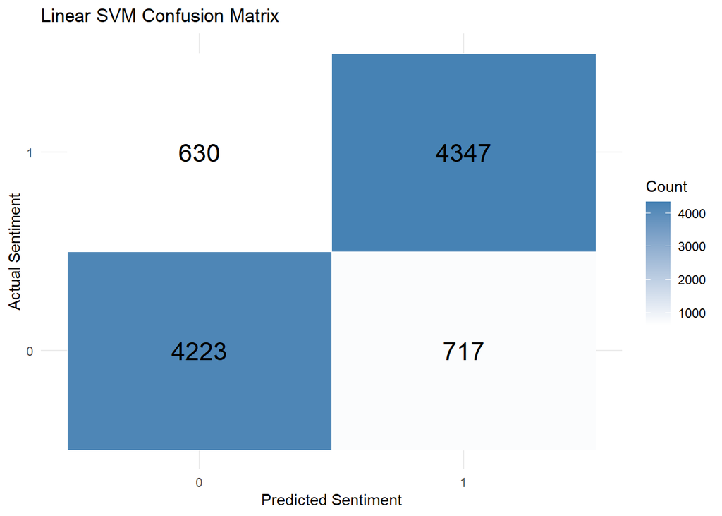

```r
svm_plot <- as.data.frame(as.table(svm_cm))
names(svm_plot) <- c("Actual", "Predicted", "Count")

ggplot(
  svm_plot,
  aes(x = Predicted, y = Actual, fill = Count)
) +
  geom_tile(color = "white") +
  geom_text(aes(label = Count), size = 6) +
  scale_fill_gradient(low = "white", high = "steelblue") +
  labs(
    title = "Linear SVM Confusion Matrix",
    x = "Predicted Sentiment",
    y = "Actual Sentiment",
    fill = "Count"
  ) +
  theme_minimal()
```

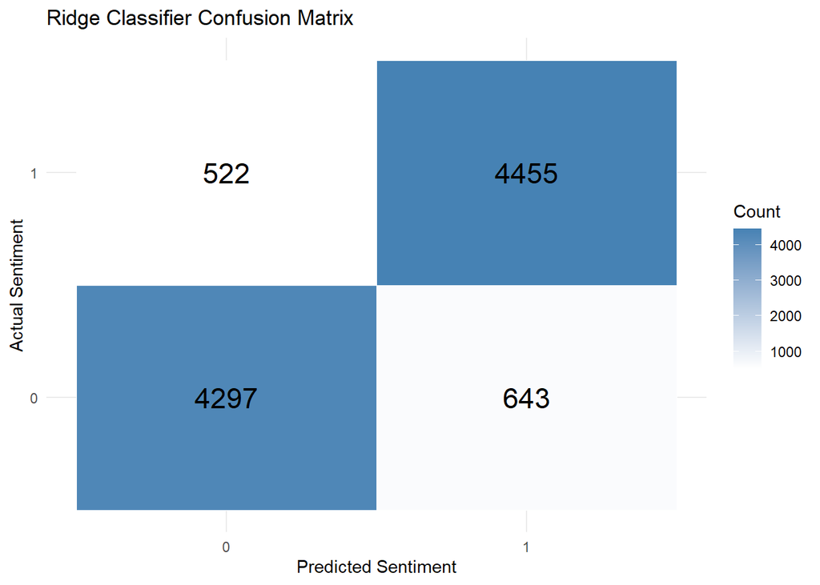

```r
ridge_plot <- as.data.frame(as.table(ridge_cm))
names(ridge_plot) <- c("Actual", "Predicted", "Count")

ggplot(
  ridge_plot,
  aes(x = Predicted, y = Actual, fill = Count)
) +
  geom_tile(color = "white") +
  geom_text(aes(label = Count), size = 6) +
  scale_fill_gradient(low = "white", high = "steelblue") +
  labs(
    title = "Ridge Classifier Confusion Matrix",
    x = "Predicted Sentiment",
    y = "Actual Sentiment",
    fill = "Count"
  ) +
  theme_minimal()
```

# 24 23. ROC Curve and AUC Analysis

Receiver Operating Characteristic (ROC) curves show the trade-off between the true positive rate and false positive rate at different classification thresholds. The Area Under the Curve (AUC) summarises the model’s ability to distinguish between the two sentiment classes.

For Logistic Regression, the same lambda value used for its class predictions is used here so that the ROC analysis corresponds to the reported classification model.

```r
logistic_prob <- as.numeric(
  predict(
    logistic_model,
    newx = dtm_test,
    type = "response",
    s = logistic_lambda
  )
)

head(logistic_prob)
```

```
## [1] 0.78504527 0.55920842 0.76936228 0.69347886 0.06296484 0.66218876
```

```r
logistic_roc <- pROC::roc(
  response = y_test,
  predictor = logistic_prob,
  levels = c(0, 1),
  direction = "<"
)

logistic_auc <- pROC::auc(logistic_roc)
logistic_auc
```

```
## Area under the curve: 0.9275
```

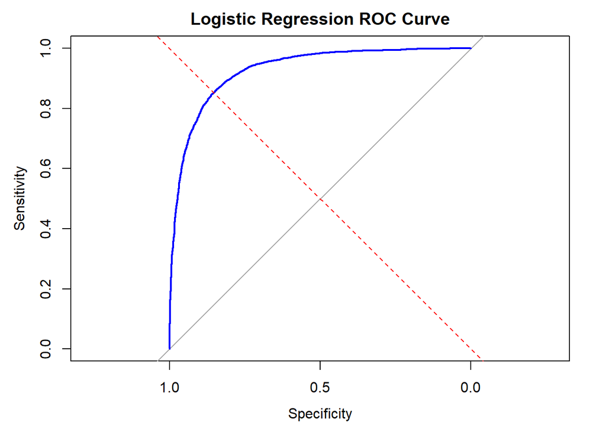

```r
plot(
  logistic_roc,
  main = "Logistic Regression ROC Curve",
  col = "blue",
  lwd = 2
)

abline(a = 0, b = 1, lty = 2, col = "red")
```

```r
naive_bayes_score <- as.numeric(
  as.matrix(positive_score - negative_score)
)

naive_bayes_prob <- plogis(naive_bayes_score)

naive_bayes_roc <- pROC::roc(
  response = y_test,
  predictor = naive_bayes_prob,
  levels = c(0, 1),
  direction = "<"
)

naive_bayes_auc <- pROC::auc(naive_bayes_roc)
naive_bayes_auc
```

```
## Area under the curve: 0.9232
```

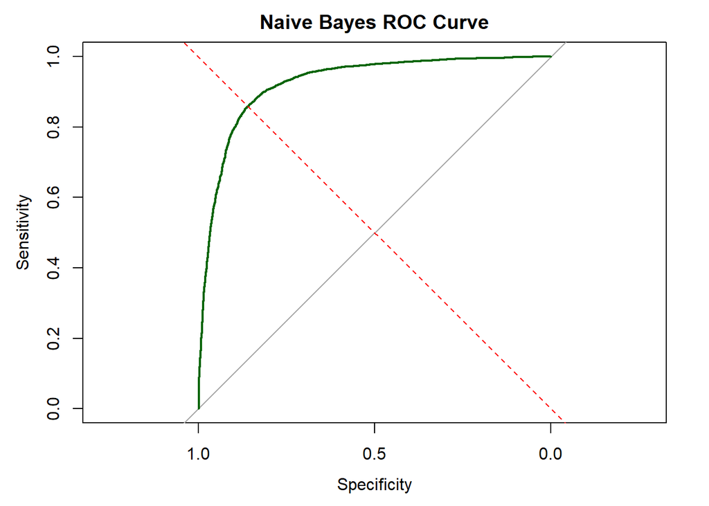

```r
plot(
  naive_bayes_roc,
  main = "Naive Bayes ROC Curve",
  col = "darkgreen",
  lwd = 2
)

abline(a = 0, b = 1, lty = 2, col = "red")
```

```r
svm_score_obj <- predict(
  svm_model,
  dtm_test_svm,
  decisionValues = TRUE
)

str(svm_score_obj)
```

```
## List of 2
##  $ predictions   : int [1:9917] 1 0 1 1 0 1 0 1 1 0 ...
##  $ decisionValues: num [1:9917, 1:2] -0.873 0.269 -1.336 -1.346 2.326 ...
##   ..- attr(*, "dimnames")=List of 2
##   .. ..$ : NULL
##   .. ..$ : chr [1:2] "0" "1"
```

```r
svm_score <- svm_score_obj$decisionValues[, "1"]

svm_roc <- pROC::roc(
  response = y_test,
  predictor = svm_score_obj$decisionValues[, "0"],
  levels = c(0, 1)
)
svm_auc <- pROC::auc(svm_roc)
svm_auc
```

```
## Area under the curve: 0.9339
```

```r
head(svm_score_obj$decisionValues)
```

```
##               0 1
## [1,] -0.8726265 0
## [2,]  0.2691649 0
## [3,] -1.3358625 0
## [4,] -1.3459101 0
## [5,]  2.3257849 0
## [6,] -0.3305187 0
```

```r
colnames(svm_score_obj$decisionValues)
```

```
## [1] "0" "1"
```

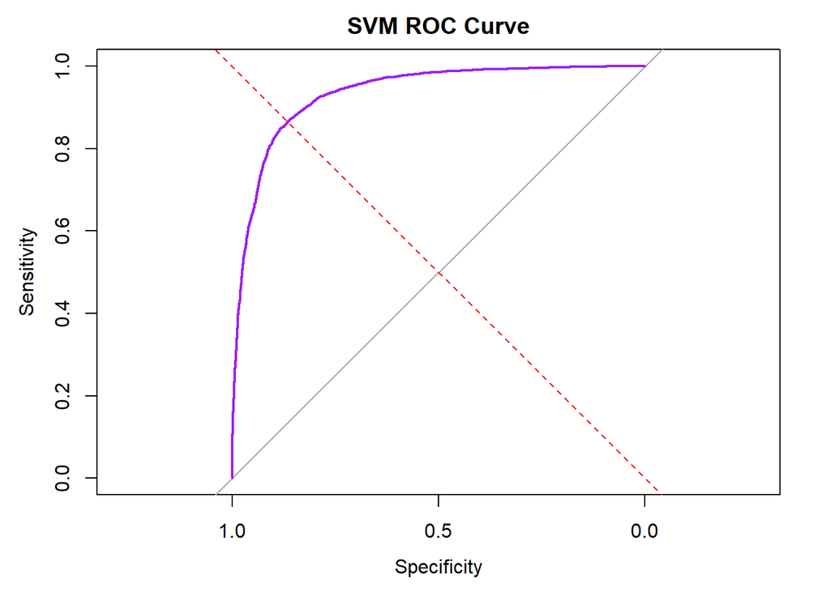

```r
plot(
  svm_roc,
  main = "SVM ROC Curve",
  col = "purple",
  lwd = 2
)

abline(a = 0, b = 1, lty = 2, col = "red")
```

```r
ridge_roc <- pROC::roc(
  response = y_test,
  predictor = as.numeric(ridge_prob),
  levels = c(0, 1),
  direction = "<"
)

ridge_auc <- pROC::auc(ridge_roc)
ridge_auc
```

```
## Area under the curve: 0.9477
```

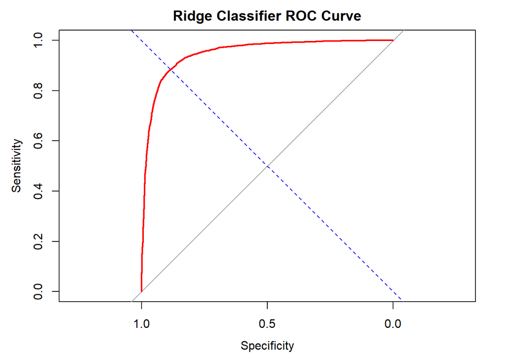

```r
plot(
  ridge_roc,
  main = "Ridge Classifier ROC Curve",
  col = "red",
  lwd = 2
)

abline(a = 0, b = 1, lty = 2, col = "blue")
```

# 25 24. Combined ROC Curve Comparison

The ROC curves of all four models are plotted together to compare their discrimination performance. The legend displays the AUC values obtained in the analysis.

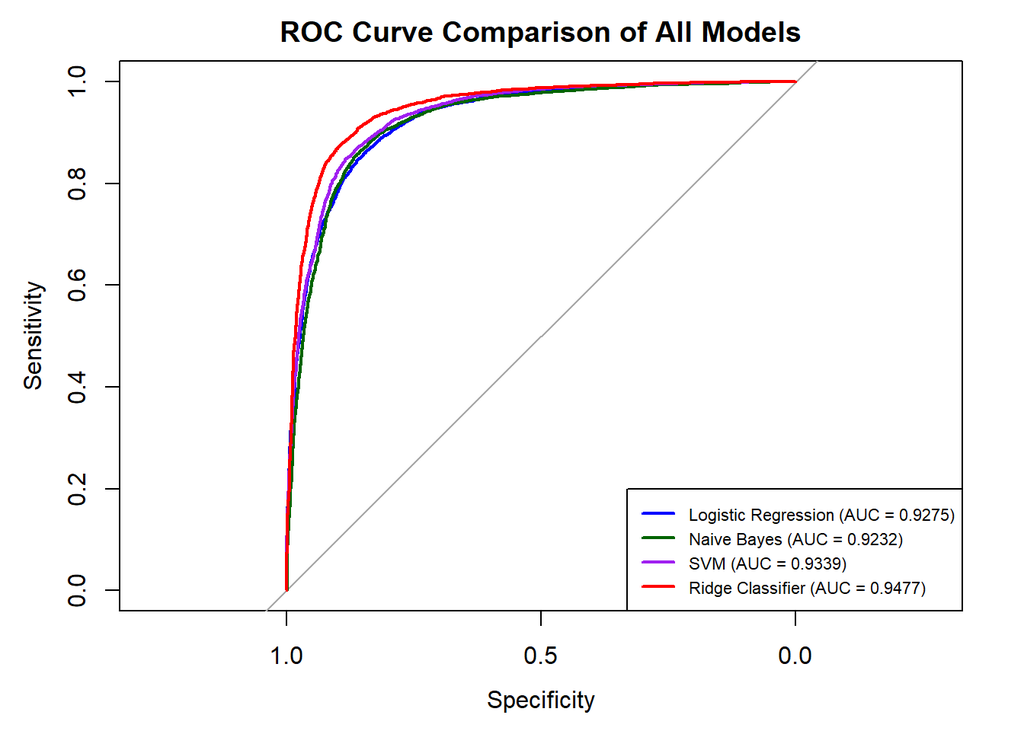

```r
plot(
  logistic_roc,
  main = "ROC Curve Comparison of All Models",
  col = "blue",
  lwd = 2
)

plot(naive_bayes_roc, add = TRUE, col = "darkgreen", lwd = 2)
plot(svm_roc, add = TRUE, col = "purple", lwd = 2)
plot(ridge_roc, add = TRUE, col = "red", lwd = 2)

legend(
  "bottomright",
  legend = c(
    paste0("Logistic Regression (AUC = ", round(as.numeric(logistic_auc), 4), ")"),
    paste0("Naive Bayes (AUC = ", round(as.numeric(naive_bayes_auc), 4), ")"),
    paste0("SVM (AUC = ", round(as.numeric(svm_auc), 4), ")"),
    paste0("Ridge Classifier (AUC = ", round(as.numeric(ridge_auc), 4), ")")
  ),
  col = c("blue", "darkgreen", "purple", "red"),
  lwd = 2,
  cex = 0.7
)
```

# 26 25. Zoomed ROC Curve Comparison

A zoomed ROC plot focuses on the upper-left region of the curve, where models generally demonstrate stronger classification performance.

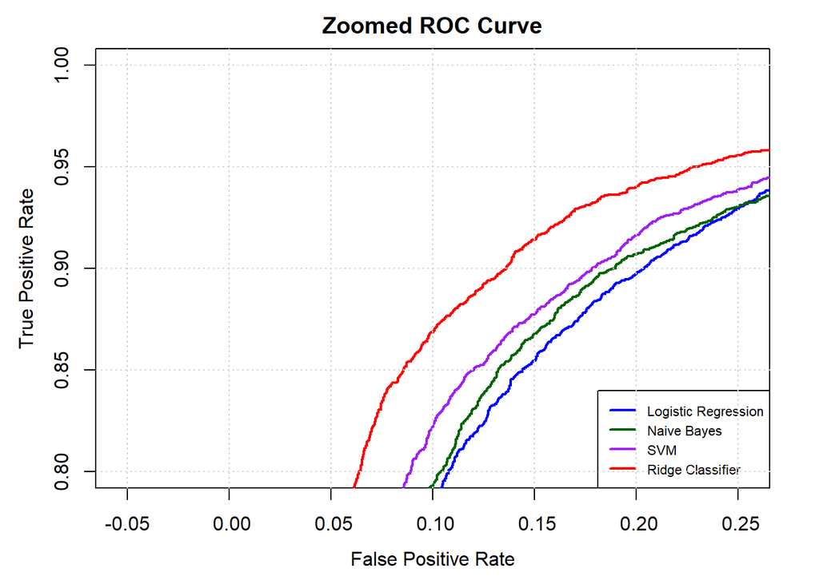

```r
plot(
  logistic_roc,
  legacy.axes = TRUE,
  xlim = c(1, 0.8),
  ylim = c(0.8, 1),
  main = "Zoomed ROC Curve",
  col = "blue",
  lwd = 2,
  xlab = "False Positive Rate",
  ylab = "True Positive Rate"
)

plot(naive_bayes_roc, add = TRUE, col = "darkgreen", lwd = 2)
plot(svm_roc, add = TRUE, col = "purple", lwd = 2)
plot(ridge_roc, add = TRUE, col = "red", lwd = 2)

legend(
  "bottomright",
  legend = c(
    "Logistic Regression",
    "Naive Bayes",
    "SVM",
    "Ridge Classifier"
  ),
  col = c("blue", "darkgreen", "purple", "red"),
  lwd = 2,
  cex = 0.7
)

grid()
```

# 27 26. LIME Model Interpretation

Local Interpretable Model-Agnostic Explanations (LIME) is used to explain an individual prediction made by the Ridge-regularised logistic regression model. A custom prediction interface converts new review text into a document-term matrix and returns the model’s predicted probabilities for the negative and positive classes.

The first review in the test dataset is selected as the example to explain.

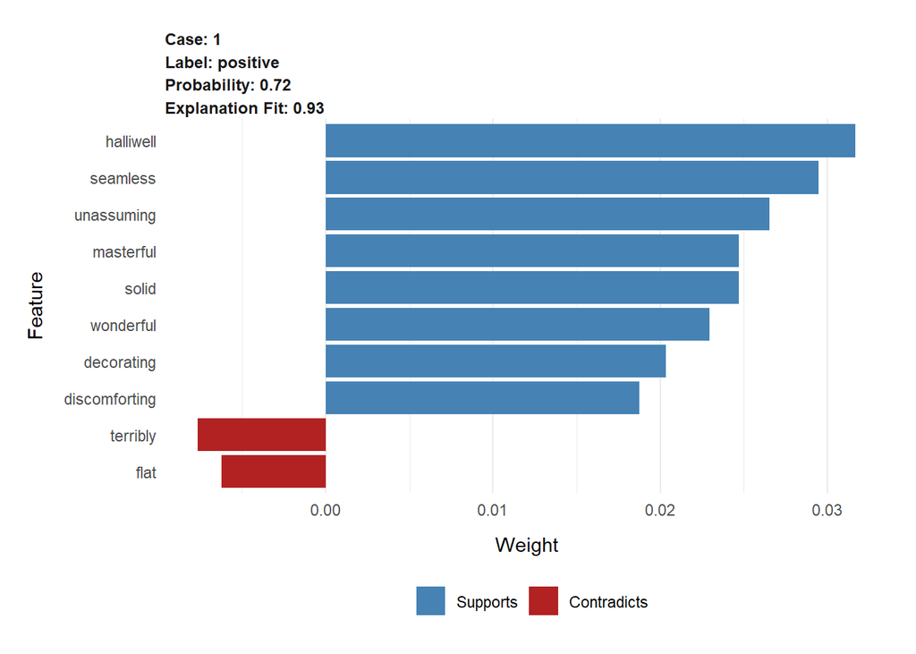

```r
ridge_classifier <- list(
  model = ridge_model,
  vectorizer = vectorizer
)

class(ridge_classifier) <- "ridge_classifier"

model_type.ridge_classifier <- function(x, ...) {
  "classification"
}

predict_model.ridge_classifier <- function(x, newdata, ...) {
  tokens <- text2vec::word_tokenizer(newdata)

  tokens <- lapply(tokens, function(words) {
    words[!words %in% tidytext::stop_words$word]
  })

  it <- text2vec::itoken(
    tokens,
    progressbar = FALSE
  )

  dtm <- text2vec::create_dtm(
    it,
    x$vectorizer
  )

  probabilities <- as.numeric(
    predict(
      x$model,
      newx = dtm,
      type = "response",
      s = x$model$lambda[15]
    )
  )

  data.frame(
    negative = 1 - probabilities,
    positive = probabilities
  )
}

explainer <- lime::lime(
  x = train_data$review,
  model = ridge_classifier,
  feature_type = "text"
)

sample_review <- test_data$review[1]

explanation <- lime::explain(
  x = sample_review,
  explainer = explainer,
  n_labels = 1,
  n_features = 10,
  n_permutations = 500
)

plot_features(explanation)
```

# 28 27. Coefficient-Based SHAP Analysis

This section calculates SHAP-style feature contributions for the Ridge-regularised logistic regression model. The contribution for each feature is calculated from the difference between the selected test review’s feature value and the training-data background mean, multiplied by the corresponding model coefficient.

The resulting values represent contributions on the model’s linear predictor (log-odds) scale. Their signs indicate the direction of the contribution to the model output, while their absolute values indicate contribution magnitude.

```r
ridge_coef <- as.matrix(
  coef(ridge_model, s = ridge_model$lambda[15])
)

feature_names <- colnames(dtm_train)

ridge_beta <- as.numeric(
  ridge_coef[feature_names, 1]
)

names(ridge_beta) <- feature_names

background_mean <- Matrix::colMeans(dtm_train)

sample_dtm <- dtm_test[1, , drop = FALSE]

sample_values <- as.numeric(as.matrix(sample_dtm))

shap_contributions <- (
  sample_values - background_mean
) * ridge_beta

shap_results <- data.frame(
  Feature = feature_names,
  SHAP_Value = as.numeric(shap_contributions)
)

shap_results <- shap_results[
  order(abs(shap_results$SHAP_Value), decreasing = TRUE),
]

head(shap_results, 10)
```

|  | Feature | SHAP_Value |
| --- | --- | --- |
| 6360 | halliwell | 0.23897283 |
| 23286 | seamless | 0.10900112 |
| 18067 | unassuming | 0.08841130 |
| 31372 | masterful | 0.08368368 |
| 34936 | wonderful | 0.07535306 |
| 34309 | solid | 0.07008210 |
| 33585 | terribly | -0.06728463 |
| 33730 | realism | 0.06274150 |
| 6041 | decorating | 0.06031717 |
| 34456 | flat | -0.05936575 |

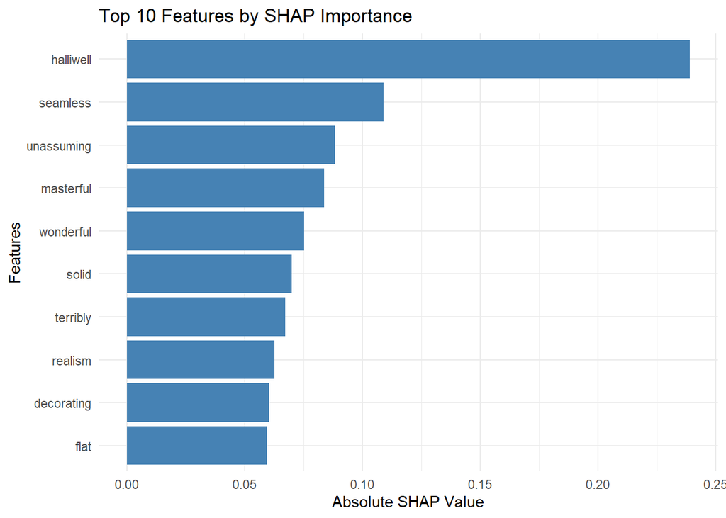

```r
ggplot(
  shap_results[1:10, ],
  aes(
    x = reorder(Feature, abs(SHAP_Value)),
    y = abs(SHAP_Value)
  )
) +
  geom_col(fill = "steelblue") +
  coord_flip() +
  labs(
    title = "Top 10 Features by SHAP Importance",
    x = "Features",
    y = "Absolute SHAP Value"
  ) +
  theme_minimal()
```

# 29 28. Project Conclusion

This project explored and processed IMDb movie reviews, examined word-level sentiment patterns, and developed four machine-learning models for binary sentiment classification. Model performance was assessed using accuracy, precision, recall, F1-score, confusion matrices, and ROC-AUC.

LIME was used to explain an individual prediction, while a coefficient-based SHAP analysis was used to examine feature contributions for a selected review. The model comparison and interpretation results can be used to discuss the strengths and limitations of the approaches.

# 30 29. Important Notes and Limitations

- The Bing lexicon analysis is based only on words present in the lexicon. It does not fully understand context, negation, sarcasm, or phrases.
- The Naive Bayes model in this script is implemented manually using word counts and Laplace smoothing.
- The SVM model uses the 3,000 most frequent training features to reduce memory use.
- The Ridge model is a logistic regression model with L2 regularisation (`alpha = 0` in `glmnet`).
- The SHAP-style calculation shown here is a coefficient-based linear-model contribution calculation using the training feature means as the background. It relies on a simplified feature contribution approach and should be described accordingly.
- The reported precision, recall, and F1 calculations use the confusion-matrix counts shown in the original analysis. If the model or dataset changes, these values should be recalculated from the corresponding confusion matrix.